# Genetic analyses

Accompanying ‘MR_CVD_MDD’

[Sander W. van der Laan, PhD](https://vanderlaanand.science) | s.w.vanderlaan@gmail.com

2025-04-10

# General Setup

```
Create a new analysis directories.

- general directory

- for plots

- for output of summary results

- for baseline tables
```

```r
source("scripts/functions.R")
```

```r
source("scripts/pack01.packages.R")
```

```
* General packages...
```

```r
Today = format(as.Date(as.POSIXlt(Sys.time())), "%Y%m%d")
Today.Report = format(as.Date(as.POSIXlt(Sys.time())), "%A, %B %d, %Y")

source("scripts/colors.R")
```

## Background

Collaboration to study MR_CVD_MDD in relation to atherosclerotic plaques characteristics.

- `Genes.xlsx` - list of genes of interest.
- `Variants.xlsx` - list of variant(s) of interest.

```r
library(openxlsx)

gene_list_df <- read.xlsx(paste0(TARGET_loc, "/targets.xlsx"), sheet = "Genes")

gene_list <- unlist(gene_list_df$Gene)
gene_list
```

```
 [1] "ADAP1"   "BAHD1"   "CHAF1A"  "DISP2"   "FAM98B"  "GNA11"   "GPR176"  "KNL1"    "MDFIC"   "MPND"    "NDUFA11" "PIP5K1C" "SUN1"    "TLE5"    "ZFAND2A"
```

```r
variant_list <- read.xlsx(paste0(TARGET_loc, "/targets.xlsx"), sheet = "Variants")

DT::datatable(variant_list)
```

|  | RSID | ALTID | VariantID | Chr | BP | A1 | A2 | FRQ_A | FRQ_U | Locus.Index | SNP.Index | VariantType | Comments |
| --- | --- | --- | --- | --- | --- | --- | --- | --- | --- | --- | --- | --- | --- |
| 1 | --- | --- | 1:8482078 | 1 | 8482078 | C | T | 0.43 | 0.43 | 1 | 1 | single nucleotide variant | PGC_MDD |
| 2 | --- | --- | 1:16126676 | 1 | 16126676 | A | G | 0.335 | 0.334 | 2 | 1 | single nucleotide variant | PGC_MDD |
| 3 | --- | --- | 1:18123443 | 1 | 18123443 | G | T | 0.141 | 0.145 | 3 | 1 | single nucleotide variant | PGC_MDD |
| 4 | --- | --- | 1:32207581 | 1 | 32207581 | G | T | 0.182 | 0.176 | 4 | 1 | single nucleotide variant | PGC_MDD |
| 5 | --- | --- | 1:35765084 | 1 | 35765084 | G | A | 0.0354 | 0.0362 | 5 | 1 | single nucleotide variant | PGC_MDD |
| 6 | --- | --- | 1:37167333 | 1 | 37167333 | T | G | 0.31 | 0.306 | 6 | 1 | single nucleotide variant | PGC_MDD |
| 7 | --- | --- | 1:37672580 | 1 | 37672580 | C | A | 0.291 | 0.288 | 7 | 1 | single nucleotide variant | PGC_MDD |
| 8 | --- | --- | 1:38431554 | 1 | 38431554 | C | T | 0.274 | 0.275 | 8 | 1 | single nucleotide variant | PGC_MDD |
| 9 | --- | --- | 1:41104664 | 1 | 41104664 | A | G | 0.475 | 0.475 | 9 | 1 | single nucleotide variant | PGC_MDD |
| 10 | --- | --- | 1:50316592 | 1 | 50316592 | T | C | 0.222 | 0.219 | 10 | 1 | single nucleotide variant | PGC_MDD |

[output cut: 612 more lines]

```r
NA
```

## This notebook

In this notebook we setup the files for the SNP analysis.

## Athero-Express Biobank Study

The [*Athero-Express Biobank Study (AE)*](http://www.atheroexpress.nl) contains plaque material of patients that underwent endarterectomyat two Dutch tertiary referral centers. Details of the study design were described before. Briefly, blood and plaque material were obtained during endarterectomy and stored at -80 ℃. Only carotid endarterectomy (CEA) patients were included in the present study. All patients provided informed consent and the study was approved by the medical ethics committee.

## Athero-Express Genomics Study

### DNA isolation and genotyping

For the *Athero-Express Genomics Study 1 (AEGS1)* 891 patients (602 males, 262 females, 27 unknown sex), included between 2002 and 2007, were genotyped (440,763 markers) using the Affymetrix Genome-Wide Human SNP Array 5.0 (SNP5) chip (Affymetrix Inc., Santa Clara, CA, USA) at [Eurofins Genomics](https://www.eurofinsgenomics.eu/) (formerly known as AROS).

For the *Athero-Express Genomics Study 2 (AEGS2)* 954 patients (640 makes, 313 females, 1 unknown sex), included between 2002 and 2013, were genotyped (587,351 markers) using the Affymetrix AxiomⓇ GW CEU 1 Array (AxM) at the [Genome Analysis Center](https://www.helmholtz-muenchen.de/no_cache/gac/index.html).

All experiments were carried out according to OECD standards.

### Genotyping calling

We used the genotyping calling algorithms as advised by Affymetrix (AEGS1 and AEGS2) and Illumina (AEGS3):

- AEGS1: BRLMM-P
- AEGS2: AxiomGT1
- AEGS3: Illumina GenomeStudio

### Imputation

Before phasing using SHAPEIT2, data was lifted to genome build b37 using the liftOver tool from UCSC (https://genome.ucsc.edu/cgi-bin/hgLiftOver). Finally, data was imputed with 1000G phase 3, version 5 and HRC release 1.1 as a reference using the [Michigan Imputation Server](https://imputationserver.sph.umich.edu/). These results were further integrated using QCTOOL v2, where HRC imputed variants are given precendence over 1000G phase 3 imputed variants.

### Quality control after imputation

We compared quality of the three AEGS datasets, and listed some variables of interest.

- sample type (EDTA blood or plaque)
- genotyping chip used
- reason for filtering

We checked the studytype (AE or not), and *identity-by-descent (IBD)* within and between datasets to aid in sample mixups, duplicate sample use, and relatedness. In addition, during genotyping quality control samples were identified that deviated from *Hardy-Weinberg Equilibrium (HWE)*, had discordance in sex-coding and genotype sex, and deviated from the *principal component analysis (PCA)* plot.

We will load the Athero-Express Biobank Study data, and all the samples that were send for genotyping and the final QC’ed sampleList.

# Loading data

Loading Athero-Express Biobank Study clinical and biobank data, as well as the SampleList of genetic data. We simply load the previously saved `RDS`-file and extract the clinical data from that.

```r
cat("* get Athero-Express Biobank Study Database...\n")
```

```
* get Athero-Express Biobank Study Database...
```

```r
AEDB.CEA <- readRDS(file = paste0(OUT_loc, "/",Today,".",TRAIT_OF_INTEREST,".AEDB.CEA.RDS"))
# AEDB.CEA <- readRDS(file = paste0(OUT_loc, "/20240109.",TRAIT_OF_INTEREST,".AEDB.CEA.RDS"))
AEDB.CEA[1:10, 1:10]
```

| STUDY_NUMBER | UPID | SMART_NUMBER | SMART_date | SMART2_date | AE_AAA_bijzonderheden | informedconsent | writtenIC | EZis | date_ic_patient |
| --- | --- | --- | --- | --- | --- | --- | --- | --- | --- |
| 1 | UPID90067 | NA |  |  | NA | yes | 1 | NA | 2014-10-09 |
| 2 | UPID01546 | NA |  |  | NA | yes | 1 | NA | 2002-04-02 |
| 3 | UPID01241 | NA |  |  | NA | yes | 1 | NA | 2002-03-25 |
| 4 | UPID01863 | NA |  |  | NA | yes | 1 | NA | 2002-03-31 |
| 5 | UPID00636 | NA |  |  | NA | yes | 1 | NA | 2002-04-17 |
| 6 | UPID00711 | NA |  |  | NA | yes | 1 | NA | 2002-04-03 |
| 7 | UPID01636 | NA |  |  | NA | yes | 1 | NA | 2002-03-23 |
| 8 | UPID01052 | NA |  |  | NA | yes | 1 | NA | 2002-04-16 |
| 9 | UPID00918 | NA |  |  | NA | yes | 1 | NA | 2002-03-21 |
| 11 | UPID01326 | NA |  |  | NA | yes | 1 | NA | 2002-04-22 |

```r
dim(AEDB.CEA)
```

```
[1] 2595 1212
```

```r
AEDB.full <- readRDS(file = paste0(OUT_loc, "/",Today,".",TRAIT_OF_INTEREST,".AEDB.FULL.RDS"))
# AEDB.full <- readRDS(file = paste0(OUT_loc, "/20240109.",TRAIT_OF_INTEREST,".AEDB.FULL.RDS"))
AEDB.full[1:10, 1:10]
```

| STUDY_NUMBER | UPID | SMART_NUMBER | SMART_date | SMART2_date | AE_AAA_bijzonderheden | informedconsent | writtenIC | EZis | date_ic_patient |
| --- | --- | --- | --- | --- | --- | --- | --- | --- | --- |
| 1 | UPID90067 | NA |  |  | NA | yes | 1 | NA | 2014-10-09 |
| 2 | UPID01546 | NA |  |  | NA | yes | 1 | NA | 2002-04-02 |
| 3 | UPID01241 | NA |  |  | NA | yes | 1 | NA | 2002-03-25 |
| 4 | UPID01863 | NA |  |  | NA | yes | 1 | NA | 2002-03-31 |
| 5 | UPID00636 | NA |  |  | NA | yes | 1 | NA | 2002-04-17 |
| 6 | UPID00711 | NA |  |  | NA | yes | 1 | NA | 2002-04-03 |
| 7 | UPID01636 | NA |  |  | NA | yes | 1 | NA | 2002-03-23 |
| 8 | UPID01052 | NA |  |  | NA | yes | 1 | NA | 2002-04-16 |
| 9 | UPID00918 | NA |  |  | NA | yes | 1 | NA | 2002-03-21 |
| 10 | UPID01934 | NA |  |  | NA | no, no reaction | 0 | NA |  |

```r
dim(AEDB.full)
```

```
[1] 4017 1212
```

```r
cat("\n* get Athero-Express Genomics Study keys...\n")
```

```
* get Athero-Express Genomics Study keys...
```

```r
AEGS123.sampleList.keytable <- fread(paste0(AEGSQC_loc, "/QC/SELECTIONS/20200419.QC.AEGS123.sampleList.keytable.txt"))

dim(AEGS123.sampleList.keytable)
```

```
[1] 2124   25
```

```r
# AEGS123.sampleList.keytable[1:10, 1:10]
```

# Athero-Express Genomics Study

## Prepare baseline

Let’s combine the full Athero-Express Biobank Study with the key-table containing the AEGS data.

> NOTE: this should sum to 2,124 samples with genotypes.

```r
AEGS <- merge(AEDB.full, AEGS123.sampleList.keytable, by.x = "STUDY_NUMBER", by.y = "STUDY_NUMBER", sort = FALSE,
                  all = TRUE)

dim(AEGS)
```

```
[1] 4018 1236
```

```r
AEGS$UPID.y <- NULL
names(AEGS)[names(AEGS) == "UPID.x"] <- "UPID"
AEGS$Age.y <- NULL
names(AEGS)[names(AEGS) == "Age.x"] <- "Age"

table(AEGS$CHIP, useNA = "ifany")
```

```
AffyAxiomCEU     AffySNP5       IllGSA         <NA>
         918          687          519         1894
```

```r
AEGS$GWAS <- AEGS$CHIP
AEGS$GWAS[is.na(AEGS$GWAS)] <- "not genotyped"
AEGS$GWAS[AEGS$GWAS != "not genotyped"] <- "genotyped"

table(AEGS$CHIP, AEGS$GWAS, useNA = "ifany")
```

```
               genotyped not genotyped
  AffyAxiomCEU       918             0
  AffySNP5           687             0
  IllGSA             519             0
  <NA>                 0          1894
```

Also a visualisation of the AEGS with AEDB overlaps.

```r
library(UpSetR)
require(ggplot2)
require(plyr)
require(gridExtra)
require(grid)

AEDB.availGWAS = list(
AEGS1 = subset(AEGS, CHIP == "AffySNP5", select = c("STUDY_NUMBER"))[,1],
AEGS2 = subset(AEGS, CHIP == "AffyAxiomCEU", select = c("STUDY_NUMBER"))[,1],
AEGS3 = subset(AEGS, CHIP == "IllGSA", select = c("STUDY_NUMBER"))[,1],
AEDB = AEGS$STUDY_NUMBER)

p1 <- UpSetR::upset(fromList(AEDB.availGWAS),
                    sets = c("AEDB", "AEGS1", "AEGS2", "AEGS3"),
                    main.bar.color = c(uithof_color[15], uithof_color[3], uithof_color[2], uithof_color[21]),
                    mainbar.y.label = "intersection sample size",
                    sets.bar.color = c(uithof_color[15], uithof_color[2], uithof_color[3], uithof_color[21]),
                    sets.x.label = "sample size", keep.order = TRUE)

p1
```

```r
pdf(paste0(PLOT_loc, "/", Today, ".overlap.AEDB_AEGS123.UpSetR.pdf"))
  p1
```

```r
dev.off()
```

```r
png(paste0(PLOT_loc, "/", Today, ".overlap.AEDB_AEGS123.UpSetR.png"))
```

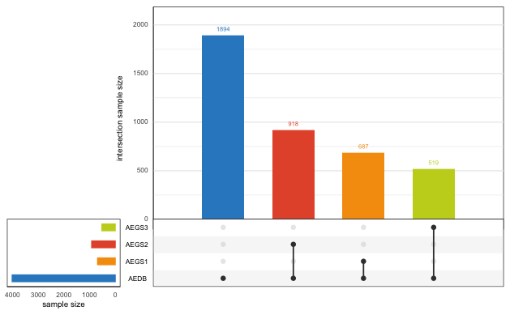

```r
  p1
dev.off()
```

```r
rm(p1)
```

> Please refer to the `AEDB.CEA.baseline.html` document for the details on the informed consent selection.

```r
table(AEGS$Artery_summary, AEGS$QC2018_FILTER)
```

```
                                                                                          family_discard family_keep issue passed
  No artery known (yet), no surgery (patient ill, died, exited study), re-numbered to AAA              0           0     0      0
  carotid (left & right)                                                                              22          21    40   1917
  femoral/iliac (left, right or both sides)                                                            1           0     0    109
  other carotid arteries (common, external)                                                            0           0     0     11
  carotid bypass and injury (left, right or both sides)                                                0           0     0      1
  aneurysmata (carotid & femoral)                                                                      0           0     0      0
  aorta                                                                                                0           0     0      0
  other arteries (renal, popliteal, vertebral)                                                         0           0     0      1
  femoral bypass, angioseal and injury (left, right or both sides)                                     0           0     0      0
```

```r
table(AEGS$informedconsent, AEGS$QC2018_FILTER)
```

```
                                                                                                  family_discard family_keep issue passed
  missing                                                                                                      0           0     0      0
  no, died                                                                                                     1           0     0     38
  yes                                                                                                         17          16    24   1411
  yes, health treatment when possible                                                                          2           2    10    312
  yes, no health treatment                                                                                     2           2     2     91
  yes, no health treatment, no commercial business                                                             0           0     0     15
  yes, no tissue, no commerical business                                                                       0           0     0      0
  yes, no tissue, no questionnaires, no medical info, no commercial business                                   0           0     0      0
  yes, no questionnaires, no health treatment, no commercial business                                          0           0     0      1
  yes, no questionnaires, health treatment when possible                                                       0           0     0      2
  yes, no tissue, no questionnaires, no health treatment, no commerical business                               0           0     0      0
  yes, no health treatment, no medical info, no commercial business                                            0           0     3     10
  yes, no tissue, no questionnaires, no health treatment, no medical info, no commercial business              0           0     0      0
  yes, no questionnaires, no health treatment                                                                  0           0     0      0
  yes, no tissue, no health treatment                                                                          0           0     0      0
  yes, no tissue, no questionnaires                                                                            0           0     0      0
  yes, no tissue, health treatment when possible                                                               0           0     0      0
  yes, no tissue                                                                                               0           0     0      0
  yes, no commerical business                                                                                  0           1     0     35
  yes, health treatment when possible, no commercial business                                                  0           0     0     25
  yes, no medical info, no commercial business                                                                 0           0     0      4
  yes, no questionnaires                                                                                       0           0     0      1
  yes, no tissue, no questionnaires, no health treatment, no medical info                                      0           0     0      0
  yes, no tissue, no questionnaires, no health treatment, no commercial business                               0           0     0      0
  yes, no medical info                                                                                         0           0     1      5
  yes, no questionnaires, no commercial business                                                               0           0     0      0
  yes, no questionnaires, no health treatment, no medical info                                                 0           0     0      1
  yes, no questionnaires, health treatment when possible, no commercial business                               0           0     0      0
  yes,  no health treatment, no medical info                                                                   0           0     0      5
```

[output cut: 16 more lines]

```r
AEGSselect <- subset(AEGS,
                     informedconsent != "missing" & # we are really strict in selecting based on 'informed consent'!
                     informedconsent != "no, died" &
                     informedconsent != "yes, no tissue, no commerical business" &
                     informedconsent != "yes, no tissue, no questionnaires, no medical info, no commercial business" &
                     informedconsent != "yes, no tissue, no questionnaires, no health treatment, no commerical business" &
                     informedconsent != "yes, no tissue, no questionnaires, no health treatment, no medical info, no commercial business" &
                     informedconsent != "yes, no tissue, no health treatment" &
                     informedconsent != "yes, no tissue, no questionnaires" &
                     informedconsent != "yes, no tissue, health treatment when possible" &
                     informedconsent != "yes, no tissue" &
                     informedconsent != "yes, no tissue, no questionnaires, no health treatment, no medical info" &
                     informedconsent != "yes, no tissue, no questionnaires, no health treatment, no commercial business" &
                     informedconsent != "no, doesn't want to" &
                     informedconsent != "no, unable to sign" &
                     informedconsent != "no, no reaction" &
                     informedconsent != "no, lost" &
                     informedconsent != "no, too old" &
                     informedconsent != "no (never asked for IC because there was no tissue)" &
                     informedconsent != "no, endpoint" &
                     informedconsent != "wil niets invullen, wel alles gebruiken" &
                     informedconsent != "nooit geincludeerd" &
                     informedconsent != "yes, no DNA")

AEGSselect.CEA <- subset(AEGS, !is.na(QC2018_FILTER) & QC2018_FILTER != "issue" & QC2018_FILTER != "family_discard" &
                     (Artery_summary == "carotid (left & right)" | Artery_summary == "other carotid arteries (common, external)") & # we only want carotids
                     informedconsent != "missing" & # we are really strict in selecting based on 'informed consent'!
                     informedconsent != "no, died" &
                     informedconsent != "yes, no tissue, no commerical business" &
                     informedconsent != "yes, no tissue, no questionnaires, no medical info, no commercial business" &
                     informedconsent != "yes, no tissue, no questionnaires, no health treatment, no commerical business" &
                     informedconsent != "yes, no tissue, no questionnaires, no health treatment, no medical info, no commercial business" &
                     informedconsent != "yes, no tissue, no health treatment" &
                     informedconsent != "yes, no tissue, no questionnaires" &
                     informedconsent != "yes, no tissue, health treatment when possible" &
                     informedconsent != "yes, no tissue" &
                     informedconsent != "yes, no tissue, no questionnaires, no health treatment, no medical info" &
                     informedconsent != "yes, no tissue, no questionnaires, no health treatment, no commercial business" &
                     informedconsent != "no, doesn't want to" &
                     informedconsent != "no, unable to sign" &
                     informedconsent != "no, no reaction" &
                     informedconsent != "no, lost" &
                     informedconsent != "no, too old" &
                     informedconsent != "no (never asked for IC because there was no tissue)" &
                     informedconsent != "no, endpoint" &
                     informedconsent != "wil niets invullen, wel alles gebruiken" &
                     informedconsent != "nooit geincludeerd" &
                     informedconsent != "yes, no DNA")

dim(AEGSselect)
```

```
[1] 3675 1235
```

```r
table(AEGSselect$Artery_summary, AEGSselect$QC2018_FILTER)
```

```
                                                                                          family_discard family_keep issue passed
  No artery known (yet), no surgery (patient ill, died, exited study), re-numbered to AAA              0           0     0      0
  carotid (left & right)                                                                              20          21    40   1814
  femoral/iliac (left, right or both sides)                                                            1           0     0     99
  other carotid arteries (common, external)                                                            0           0     0      9
  carotid bypass and injury (left, right or both sides)                                                0           0     0      1
  aneurysmata (carotid & femoral)                                                                      0           0     0      0
  aorta                                                                                                0           0     0      0
  other arteries (renal, popliteal, vertebral)                                                         0           0     0      1
  femoral bypass, angioseal and injury (left, right or both sides)                                     0           0     0      0
```

```r
table(AEGSselect$Artery_summary, AEGSselect$CHIP)
```

```
                                                                                          AffyAxiomCEU AffySNP5 IllGSA
  No artery known (yet), no surgery (patient ill, died, exited study), re-numbered to AAA            0        0      0
  carotid (left & right)                                                                           860      550    485
  femoral/iliac (left, right or both sides)                                                          0       72     28
  other carotid arteries (common, external)                                                          2        5      2
  carotid bypass and injury (left, right or both sides)                                              0        1      0
  aneurysmata (carotid & femoral)                                                                    0        0      0
  aorta                                                                                              0        0      0
  other arteries (renal, popliteal, vertebral)                                                       0        1      0
  femoral bypass, angioseal and injury (left, right or both sides)                                   0        0      0
```

```r
table(AEGSselect$QC2018_FILTER, AEGSselect$CHIP)
```

```
                 AffyAxiomCEU AffySNP5 IllGSA
  family_discard           12        6      3
  family_keep               8        1     12
  issue                    37        1      2
  passed                  805      621    498
```

```r
table(AEGSselect$QC2018_FILTER, AEGSselect$SAMPLE_TYPE)
```

```
                 EDTA_blood plaque unknown
  family_discard         15      6       0
  family_keep            13      8       0
  issue                  26     14       0
  passed               1200    723       1
```

```r
AEDB.temp <- subset(AEGSselect,  select = c("STUDY_NUMBER", "UPID", "Age", "Gender", "Hospital", "Artery_summary", "QC2018_FILTER", "CHIP", "SAMPLE_TYPE"))
require(labelled)
AEDB.temp$Gender <- to_factor(AEDB.temp$Gender)
AEDB.temp$Hospital <- to_factor(AEDB.temp$Hospital)
AEDB.temp$Artery_summary <- to_factor(AEDB.temp$Artery_summary)
AEDB.temp$QC2018_FILTER <- to_factor(AEDB.temp$QC2018_FILTER)
AEDB.temp$CHIP <- to_factor(AEDB.temp$CHIP)
AEDB.temp$SAMPLE_TYPE <- to_factor(AEDB.temp$SAMPLE_TYPE)

DT::datatable(AEDB.temp[1:10,], caption = "Excerpt of the whole AEDB.", rownames = FALSE)
```

| STUDY_NUMBER | UPID | Age | Gender | Hospital | Artery_summary | QC2018_FILTER | CHIP | SAMPLE_TYPE |
| --- | --- | --- | --- | --- | --- | --- | --- | --- |
| 1 | UPID90067 | 63 | male | St. Antonius, Nieuwegein | carotid (left &amp; right) | issue | AffySNP5 | EDTA_blood |
| 4 | UPID01863 | 79 | female | St. Antonius, Nieuwegein | carotid (left &amp; right) | passed | AffySNP5 | EDTA_blood |
| 5 | UPID00636 | 68 | male | St. Antonius, Nieuwegein | carotid (left &amp; right) | passed | AffyAxiomCEU | EDTA_blood |
| 6 | UPID00711 | 68 | male | St. Antonius, Nieuwegein | carotid (left &amp; right) | passed | AffyAxiomCEU | EDTA_blood |
| 7 | UPID01636 | 63 | male | St. Antonius, Nieuwegein | carotid (left &amp; right) | passed | AffySNP5 | EDTA_blood |
| 8 | UPID01052 | 66 | male | St. Antonius, Nieuwegein | carotid (left &amp; right) | passed | AffySNP5 | EDTA_blood |
| 9 | UPID00918 | 74 | male | St. Antonius, Nieuwegein | carotid (left &amp; right) | passed | AffySNP5 | EDTA_blood |
| 11 | UPID01326 | 63 | male | St. Antonius, Nieuwegein | carotid (left &amp; right) | passed | AffySNP5 | EDTA_blood |
| 12 | UPID00169 | 74 | male | St. Antonius, Nieuwegein | carotid (left &amp; right) | passed | AffySNP5 | EDTA_blood |
| 13 | UPID00678 | 60 | female | St. Antonius, Nieuwegein | carotid (left &amp; right) | passed | AffySNP5 | EDTA_blood |

```r
rm(AEDB.temp)
```

## Athero-Express Genomics Study Baseline Characteristics

Showing the baseline table of the Athero-Express Genomics Study.

```r
# Create baseline tables
# http://rstudio-pubs-static.s3.amazonaws.com/13321_da314633db924dc78986a850813a50d5.html
AEGSselect$GWAS <- to_factor(AEGSselect$GWAS)
AEGSselect$CHIP <- to_factor(AEGSselect$CHIP)
AEGSselect$PCA <- to_factor(AEGSselect$PCA)
AEGSselect$SAMPLE_TYPE <- to_factor(AEGSselect$SAMPLE_TYPE)
AEGSselect$informedconsent <- to_factor(AEGSselect$informedconsent)
AEGSselect$Artery_summary <- to_factor(AEGSselect$Artery_summary)

AEGSselect.CEA$GWAS <- to_factor(AEGSselect.CEA$GWAS)
AEGSselect.CEA$CHIP <- to_factor(AEGSselect.CEA$CHIP)
AEGSselect.CEA$PCA <- to_factor(AEGSselect.CEA$PCA)
AEGSselect.CEA$SAMPLE_TYPE <- to_factor(AEGSselect.CEA$SAMPLE_TYPE)
AEGSselect.CEA$informedconsent <- to_factor(AEGSselect.CEA$informedconsent)
AEGSselect.CEA$Artery_summary <- to_factor(AEGSselect.CEA$Artery_summary)

cat("===========================================================================================\n")
cat("CREATE BASELINE TABLE\n")
```

```
CREATE BASELINE TABLE
```

```r
# Baseline table variables
basetable_vars = c("Hospital",
                   "Age", "Gender",
                   "TC_final", "LDL_final", "HDL_final", "TG_final",
                   "systolic", "diastoli", "GFR_MDRD", "BMI",
                   "KDOQI", "BMI_WHO",
                   "SmokerCurrent", "eCigarettes", "ePackYearsSmoking",
                   "DiabetesStatus", "Hypertension.selfreport", "Hypertension.selfreportdrug", "Hypertension.composite",
                   "Hypertension.drugs", "Med.anticoagulants", "Med.all.antiplatelet", "Med.Statin.LLD",
                   "Stroke_Dx", "sympt", "Symptoms.5G", "restenos",
                   "EP_composite", "EP_composite_time",
                   "macmean0", "smcmean0", "Macrophages.bin", "SMC.bin", "neutrophils", "Mast_cells_plaque", "vessel_density_averaged",
                   "IPH.bin",
                   "Calc.bin", "Collagen.bin",
                   "Fat.bin_10", "Fat.bin_40", "OverallPlaquePhenotype", "Plaque_Vulnerability_Index",
                   "SMC_rankNorm", "MAC_rankNorm", "Neutrophils_rankNorm", "MastCells_rankNorm", "VesselDensity_rankNorm",
                   "GWAS", "CHIP", "PCA", "Artery_summary",
                   "PCSK9_plasma", "PCSK9_plasma_rankNorm")

basetable_bin = c("Gender",
                  "KDOQI", "BMI_WHO",
                  "SmokerCurrent",
                  "DiabetesStatus", "Hypertension.selfreport", "Hypertension.selfreportdrug", "Hypertension.composite",
                  "Hypertension.drugs", "Med.anticoagulants", "Med.all.antiplatelet", "Med.Statin.LLD",
                  "Stroke_Dx", "sympt", "Symptoms.5G", "restenos",
                  "EP_composite", "Macrophages.bin", "SMC.bin",
                  "IPH.bin",
                  "Calc.bin", "Collagen.bin",
                  "Fat.bin_10", "Fat.bin_40", "OverallPlaquePhenotype", "Plaque_Vulnerability_Index",
                  "GWAS", "CHIP", "PCA", "Artery_summary")

basetable_bin
```

```
 [1] "Gender"                      "KDOQI"                       "BMI_WHO"                     "SmokerCurrent"               "DiabetesStatus"
 [6] "Hypertension.selfreport"     "Hypertension.selfreportdrug" "Hypertension.composite"      "Hypertension.drugs"          "Med.anticoagulants"
[11] "Med.all.antiplatelet"        "Med.Statin.LLD"              "Stroke_Dx"                   "sympt"                       "Symptoms.5G"
[16] "restenos"                    "EP_composite"                "Macrophages.bin"             "SMC.bin"                     "IPH.bin"
[21] "Calc.bin"                    "Collagen.bin"                "Fat.bin_10"                  "Fat.bin_40"                  "OverallPlaquePhenotype"
[26] "Plaque_Vulnerability_Index"  "GWAS"                        "CHIP"                        "PCA"                         "Artery_summary"
```

```r
basetable_con = basetable_vars[!basetable_vars %in% basetable_bin]
basetable_con
```

```
 [1] "Hospital"                "Age"                     "TC_final"                "LDL_final"               "HDL_final"               "TG_final"
 [7] "systolic"                "diastoli"                "GFR_MDRD"                "BMI"                     "eCigarettes"             "ePackYearsSmoking"
[13] "EP_composite_time"       "macmean0"                "smcmean0"                "neutrophils"             "Mast_cells_plaque"       "vessel_density_averaged"
[19] "SMC_rankNorm"            "MAC_rankNorm"            "Neutrophils_rankNorm"    "MastCells_rankNorm"      "VesselDensity_rankNorm"  "PCSK9_plasma"
[25] "PCSK9_plasma_rankNorm"
```

```r
cat("\n===========================================================================================\n")
cat("DISPLAY BASELINE TABLE\n")

AEGSselect.tableOne = print(CreateTableOne(vars = basetable_vars,
                                         # factorVars = basetable_bin,
                                         strata = "GWAS",
                                         data = AEGSselect, includeNA = TRUE),
                          nonnormal = c(), missing = TRUE,
                          quote = FALSE, noSpaces = FALSE, showAllLevels = TRUE, explain = TRUE,
                          format = "pf",
                          contDigits = 3)[,1:6]
```

Baseline of the valid, CEA and genotyped data.

```r
AEGSselect.CEA.tableOne = print(CreateTableOne(vars = basetable_vars,
                                         # factorVars = basetable_bin,
                                         strata = "Gender",
                                         data = AEGSselect.CEA, includeNA = TRUE),
                          nonnormal = c(), missing = TRUE,
                          quote = FALSE, noSpaces = FALSE, showAllLevels = TRUE, explain = TRUE,
                          format = "pf",
                          contDigits = 3)[,1:6]
```

### Baseline writing

Let’s save the baseline characteristics of the Athero-Express Genomics Study.

```r
# Write basetable
require(openxlsx)

write.xlsx(file = paste0(BASELINE_loc, "/",Today,".",PROJECTNAME,".AEGS.BaselineTable.xlsx"),
           format(as.data.frame(AEGSselect.tableOne), digits = 5, scientific = FALSE),
           rowNames = TRUE,
           colNames = TRUE,
           sheetName = "AEGS_Base_AEDB", overwrite = TRUE)

write.xlsx(file = paste0(BASELINE_loc, "/",Today,".",PROJECTNAME,".AEGS.CEA.BaselineTable.xlsx"),
           format(as.data.frame(AEGSselect.CEA.tableOne), digits = 5, scientific = FALSE),
           rowNames = TRUE,
           colNames = TRUE,
           sheetName = "AEGS_Base_CEA_sex", overwrite = TRUE)
```

# AE eQTL Study (b37, n=626) baseline characteristics

Here we will load the list of samples that have overlapping genotype and transcriptomic data, and we will create a baseline table for these samples. These samples are derived from the molQTL analyses done using QTLToolKit.

```r
library(openxlsx)

# update list
SampleList_eQTL_b37 <- read.xlsx(paste0(TARGET_loc, "/SampleList_eQTL_b37.xlsx"), sheet = "SampleList_eQTL_b37")

DT::datatable(SampleList_eQTL_b37)
```

|  | SampleID | Order |
| --- | --- | --- |
| 1 | UPID00196_1618 | 1 |
| 2 | UPID02214_2089 | 2 |
| 3 | UPID02284_2276 | 3 |
| 4 | UPID00791-UPID00791-A318-0577 | 4 |
| 5 | UPID00490-UPID00490-A318-0540 | 5 |
| 6 | UPID00256-UPID00256-A318-0686 | 6 |
| 7 | UPID01245_1218 | 7 |
| 8 | UPID01102_207 | 8 |
| 9 | UPID02334_2327 | 9 |
| 10 | UPID01807-UPID01807-A318-0564 | 10 |

[output cut: 616 more lines]

Let’s match this list with the AEGS dataset, as this will have the genotype SampleID.

```r
# Matching the SampleList_eQTL_b37 with the AEGS dataset
# ID_1 = SampleID

# AEGS_eQTL <- merge(AEGSselect, SampleList_eQTL_b37,
#                    by.x = "ID_1",
#                    by.y = "SampleID",
#                    sort = FALSE,
#                    all.y = TRUE)

AEGS_eQTL <- merge(AEGS, SampleList_eQTL_b37,
                   by.x = "ID_1",
                   by.y = "SampleID",
                   sort = FALSE,
                   all.y = TRUE)
```

```r
library(gtsummary)
library(dplyr)

# Drop variables that have <2 levels across the full dataset
# This is to prevent the message:
# The following errors were returned during `add_p()`:✖ For variable `GWAS` (`Gender`) and "statistic", "p.value", and "parameter" statistics: 'x' and 'y' must have at least 2 levels
clean_vars <- basetable_vars[sapply(AEGS_eQTL[basetable_vars], function(x) nlevels(factor(x)) > 1)]

# Create the summary table, stratified by Gender
AEGS_eQTL.sex.tbl <- AEGS_eQTL %>%
  select(all_of(clean_vars), Gender) %>%
  tbl_summary(
    by = Gender,
    missing = "ifany",
    statistic = all_continuous() ~ "{mean} ({sd})"
  ) %>%
  add_p(test.args = all_categorical() ~ list(simulate.p.value = TRUE)) %>%
  bold_labels()

# Create the summary table
AEGS_eQTL.tbl <- AEGS_eQTL %>%
  select(all_of(clean_vars)) %>%
  tbl_summary(
    # by = Gender,
    missing = "ifany",
    statistic = all_continuous() ~ "{mean} ({sd})"
  ) %>%
  add_n %>%
  bold_labels()
```

```r
library(writexl)

# Convert to a clean data frame
AEGS_eQTL.sex.tbl_df <- AEGS_eQTL.sex.tbl %>% as_tibble()

# Save to Excel
write.xlsx(AEGS_eQTL.sex.tbl_df,
           file = paste0(BASELINE_loc, "/",Today,".",PROJECTNAME,".AEGS_eQTL.Gender.BaselineTable.xlsx"),
           rowNames = FALSE,
           colNames = TRUE,
           sheetName = "AEGS_eQTL_gender", overwrite = TRUE)

# Convert to a clean data frame
AEGS_eQTL.tbl_df <- AEGS_eQTL.tbl %>% as_tibble()

# Save to Excel
write.xlsx(AEGS_eQTL.tbl_df,
           file = paste0(BASELINE_loc, "/",Today,".",PROJECTNAME,".AEGS_eQTL.BaselineTable.xlsx"),
           rowNames = FALSE,
           colNames = TRUE,
           sheetName = "AEGS_eQTL", overwrite = TRUE)
```

```r
library(officer)
library(flextable)

# Format for Word output with Calibri font and size 9, stratified by Gender
ft <- gtsummary::as_flex_table(AEGS_eQTL.sex.tbl) %>%
  theme_vanilla() %>%
  autofit() %>%
  set_table_properties(layout = "autofit") %>%
  flextable::font(fontname = "Calibri", part = "all") %>%
  flextable::fontsize(size = 9, part = "all")

# Save to Word
doc <- read_docx() %>%
  body_add_par("Table 1. Baseline characteristics Athero-Express Biobank Study - eQTL data only (b37, n=626), stratified by Gender") %>%
  body_add_flextable(ft)
print(doc, target = paste0(BASELINE_loc, "/",Today,".",PROJECTNAME,".AEGS_eQTL.Gender.BaselineTable.docx"))

# Print message
message("Table exported successfully to *.AEGS_eQTL.Gender.BaselineTable.xlsx and *.AEGS_eQTL.Gender.BaselineTable.docx with Calibri font and size 9.")
```

```
Table exported successfully to *.AEGS_eQTL.Gender.BaselineTable.xlsx and *.AEGS_eQTL.Gender.BaselineTable.docx with Calibri font and size 9.
```

```r
rm(ft, doc)

# Format for Word output with Calibri font and size 9
ft <- gtsummary::as_flex_table(AEGS_eQTL.tbl) %>%
  theme_vanilla() %>%
  autofit() %>%
  set_table_properties(layout = "autofit") %>%
  flextable::font(fontname = "Calibri", part = "all") %>%
  flextable::fontsize(size = 9, part = "all")

# Save to Word
doc <- read_docx() %>%
  body_add_par("Table 1. Baseline characteristics Athero-Express Biobank Study - eQTL data only (b37, n=626)") %>%
  body_add_flextable(ft)
print(doc, target = paste0(BASELINE_loc, "/",Today,".",PROJECTNAME,".AEGS_eQTL.BaselineTable.docx"))

# Print message
message("Table exported successfully to *.AEGS_eQTL.BaselineTable.xlsx and *.AEGS_eQTL.BaselineTable.docx with Calibri font and size 9.")
```

```
Table exported successfully to *.AEGS_eQTL.BaselineTable.xlsx and *.AEGS_eQTL.BaselineTable.docx with Calibri font and size 9.
```

```r
rm(ft, doc)
```

Let’s also display the baseline data.

```r
AEGS_eQTL.sex.tbl
```

| **Characteristic** | **female** N = 165<sup>1</sup> | **male** N = 461<sup>1</sup> | **p-value**<sup>2</sup> |
| --- | --- | --- | --- |
| Hospital |  |  | 0.2 |
| St. Antonius, Nieuwegein | 102 (62%) | 256 (56%) |  |
| UMC Utrecht | 63 (38%) | 205 (44%) |  |
| Age | 68 (10) | 69 (9) | 0.7 |
| TC_final | 4.90 (1.34) | 4.58 (1.20) | 0.013 |
| Unknown | 50 | 141 |  |
| LDL_final | 2.82 (1.07) | 2.75 (1.03) | 0.3 |
| Unknown | 61 | 174 |  |
| HDL_final | 1.29 (0.42) | 1.10 (0.34) | <0.001 |
| Unknown | 55 | 161 |  |
| TG_final | 1.58 (0.89) | 1.64 (0.95) | 0.4 |
| Unknown | 56 | 157 |  |
| systolic | 155 (25) | 154 (25) | 0.6 |
| Unknown | 23 | 79 |  |
| diastoli | 82 (13) | 83 (14) | 0.5 |
| Unknown | 23 | 79 |  |
| GFR_MDRD | 71 (21) | 74 (21) | 0.14 |
| Unknown | 2 | 4 |  |
| BMI | 26.7 (4.6) | 26.6 (3.5) | 0.9 |
| Unknown | 17 | 23 |  |
| KDOQI |  |  | 0.5 |
| No data available/missing | 0 (0%) | 0 (0%) |  |
| Normal kidney function | 26 (16%) | 89 (19%) |  |
| CKD 2 (Mild) | 91 (56%) | 251 (55%) |  |
| CKD 3 (Moderate) | 43 (26%) | 110 (24%) |  |
| CKD 4 (Severe) | 2 (1.2%) | 7 (1.5%) |  |
| CKD 5 (Failure) | 1 (0.6%) | 0 (0%) |  |
| Unknown | 2 | 4 |  |
| BMI_WHO |  |  | 0.3 |
| No data available/missing | 0 (0%) | 0 (0%) |  |

[output cut: 177 more lines]

<sup>1</sup> n (%); Mean (SD)  
<sup>2</sup> Pearson’s Chi-squared test with simulated p-value (based on 2000 replicates); Wilcoxon rank sum test; Fisher’s Exact Test for Count Data with simulated p-value (based on 2000 replicates); Fisher’s exact test

```r
AEGS_eQTL.tbl
```

| **Characteristic** | **N** | **N = 626**<sup>1</sup> |
| --- | --- | --- |
| Hospital | 626 |  |
| St. Antonius, Nieuwegein |  | 358 (57%) |
| UMC Utrecht |  | 268 (43%) |
| Age | 626 | 69 (9) |
| Gender | 626 |  |
| female |  | 165 (26%) |
| male |  | 461 (74%) |
| TC_final | 435 | 4.66 (1.24) |
| Unknown |  | 191 |
| LDL_final | 391 | 2.77 (1.04) |
| Unknown |  | 235 |
| HDL_final | 410 | 1.15 (0.37) |
| Unknown |  | 216 |
| TG_final | 413 | 1.62 (0.94) |
| Unknown |  | 213 |
| systolic | 524 | 155 (25) |
| Unknown |  | 102 |
| diastoli | 524 | 82 (13) |
| Unknown |  | 102 |
| GFR_MDRD | 620 | 73 (21) |
| Unknown |  | 6 |
| BMI | 586 | 26.6 (3.8) |
| Unknown |  | 40 |
| KDOQI | 620 |  |
| No data available/missing |  | 0 (0%) |
| Normal kidney function |  | 115 (19%) |
| CKD 2 (Mild) |  | 342 (55%) |
| CKD 3 (Moderate) |  | 153 (25%) |
| CKD 4 (Severe) |  | 9 (1.5%) |
| CKD 5 (Failure) |  | 1 (0.2%) |

[output cut: 180 more lines]

<sup>1</sup> n (%); Mean (SD)

## Save AEGS_eQTL

Save the `AEGS_eQTL` dataset for further use downstream.

```r
# Save the AEGS_eQTL dataset
saveRDS(AEGS_eQTL, file = paste0(OUT_loc, "/",Today,".",PROJECTNAME,".AEGS_eQTL.RDS"))
```

# Session information

```
Version:      v1.3.1
Last update:  2025-04-10
Written by:   Sander W. van der Laan (s.w.vanderlaan-2[at]umcutrecht.nl).
Description:  Script to get some Athero-Express Biobank Study baseline characteristics.
Minimum requirements: R version 3.4.3 (2017-06-30) -- 'Single Candle', Mac OS X El Capitan

Changes log
* v1.3.1 Fixed an issue where the Word-document output was not working properly.
* v1.3.0 Added baseline table writing of eQTL data subset.
* v1.2.2 Textual fixes.
* v1.2.1 Fixed issue with baseline writing.
* v1.2.0 Update to the study database.
* v1.1.0 Major update to WORCS system.
* v1.0.6 Small bug fixes.
* v1.0.5 Added png for overlap-figure.
* v1.0.5 Removed obsolete references to objects.
* v1.0.4 Fixed a mistake in the chr X sample-file creation. Now the order matches the chr X data.
* v1.0.3 Fixed weight of files (limit of 10Mb per file for templates). Renamed entire repo.
* v1.0.2 Added sex-specific .sample-files. Added GWASToolKit input-files.
* v1.0.0 Initial version. Add 'plaque vulnerability index', Fixed baseline table, added codes, and results. Created sample-files.
```

# Saving environment

```r
save.image(paste0(PROJECT_loc, "/",Today,".",PROJECTNAME,".SNP_analyses.RData"))
```

| <sup>© 1979-2025 Sander W. van der Laan \| s.w.vanderlaan[at]gmail.com \| vanderlaanand.science.</sup> \| |
| --- |